# Portfoliomanagement and Financial Analysis - Assignment 5

Submit until Monday 2020-10-19, 13:00

Schwaiger, Dominik

```r
#remotes::install_github("braverock/PortfolioAnalytics",  build_vignettes = TRUE, force = TRUE)
pacman::p_load(tidyverse,tidyquant,FFdownload,PortfolioAnalytics,nloptr)
```

**Please** remember to put your assignment solutions in `rmd` format using **many** chunks and putting readable text in between, similar to my examples given in Research Methods and Assignment 1! Also, each student has to select his own set of 10 stocks having data available as of `2000-01-01`. Select by Sharpe-ratio, dominance or any other method (e.g. matching your first name).

For all exercises: Please use the Assignment-Forum to post your questions, I will try my best to help you along!

# revised Exercise 1

## Exercise 1: Constraints

Have a look at `vignette("portfolio_vignette")`. Use your dataset to compute

1. Minimum-Variance
2. Maximum Quadratic Utility Portfolios

adding (individually/together) all the different constraints and highlighting the different portfolios (portfolios performances) including rebalancing over an appropriate time-frame. The goal is, that after doing this exercise you are familiar with the constraints and their consequences.

First, we download the data. I use the following stocks (=same as in the previous assignments:

-“AMZN” -“ADBE” -“MSFT” -“JNJ” -“PG” -“AXP” -“BAC” -“AAPL” -“T” -“CAT”

We get the data and transmute it to returns.

```r
stockselection <- c("AMZN","ADBE","MSFT","JNJ","PG","AXP","BAC","AAPL","T","CAT")
stock.prices <- stockselection %>%
  tq_get(get  = "stock.prices", from = "2000-01-01",to = "2020-09-30") %>%
  group_by(symbol)
stock.prices
```

| symbol | date | open | high | low | close | volume | adjusted |
| --- | --- | --- | --- | --- | --- | --- | --- |
| AMZN | 2000-01-03 | 81.50000 | 89.56250 | 79.04688 | 89.3750 | 16117600 | 89.3750 |
| AMZN | 2000-01-04 | 85.37500 | 91.50000 | 81.75000 | 81.9375 | 17487400 | 81.9375 |
| AMZN | 2000-01-05 | 70.50000 | 75.12500 | 68.00000 | 69.7500 | 38457400 | 69.7500 |
| AMZN | 2000-01-06 | 71.31250 | 72.68750 | 64.00000 | 65.5625 | 18752000 | 65.5625 |
| AMZN | 2000-01-07 | 67.00000 | 70.50000 | 66.18750 | 69.5625 | 10505400 | 69.5625 |
| AMZN | 2000-01-10 | 72.56250 | 72.62500 | 65.56250 | 69.1875 | 14757900 | 69.1875 |
| AMZN | 2000-01-11 | 66.87500 | 70.00000 | 65.00000 | 66.7500 | 10532700 | 66.7500 |
| AMZN | 2000-01-12 | 67.87500 | 68.00000 | 63.00000 | 63.5625 | 10804500 | 63.5625 |
| AMZN | 2000-01-13 | 64.93750 | 67.18750 | 63.12500 | 65.9375 | 10448100 | 65.9375 |
| AMZN | 2000-01-14 | 66.75000 | 68.62500 | 64.00000 | 64.2500 | 6853600 | 64.2500 |

[output cut: 50 more lines]

Next, we create monthly returns.

```r
stock.returns.monthly <- stock.prices %>%
  tq_transmute(select = adjusted,
               mutate_fun = periodReturn,
               period="monthly",
               type="arithmetic",
               col_rename = "Stock.returns"
               )
stock.returns.monthly
```

| symbol | date | Stock.returns |
| --- | --- | --- |
| AMZN | 2000-01-31 | -0.277622378 |
| AMZN | 2000-02-29 | 0.066795741 |
| AMZN | 2000-03-31 | -0.027223230 |
| AMZN | 2000-04-28 | -0.176305970 |
| AMZN | 2000-05-31 | -0.124575311 |
| AMZN | 2000-06-30 | -0.248382924 |
| AMZN | 2000-07-31 | -0.170395869 |
| AMZN | 2000-08-31 | 0.377593361 |
| AMZN | 2000-09-29 | -0.073795181 |
| AMZN | 2000-10-31 | -0.047154472 |

[output cut: 50 more lines]

In this step, we put it into a tibble.

```r
R <- pivot_wider(stock.returns.monthly,
                                                names_from = symbol,
                                                values_from = c(Stock.returns))%>%
  tk_xts(date_var = date, silent = TRUE)

tk_xts
```

[output not shown]

```r
#colnames(R) <- stockselection #nachschauen was für eine Funktion colnames hat
#funds <- colnames(R)
```

### a) Minimum Variance Portfolio

#### Mininum Variance Portfolio with Full investment Constraint

The first example is with the full investment constraint. For this, we create our min-var portfolio and add the constraint. After that, we add the objective to minimize the variance.

```r
portf_minvar <- portfolio.spec(assets=stockselection)
portf_minvar <- add.constraint(portfolio=portf_minvar, type="full_investment")
portf_minvar <- add.objective(portfolio=portf_minvar, type="risk", name="var")
portf_minvar
```

```
PortfolioAnalytics Portfolio Specification

Call:
portfolio.spec(assets = stockselection)

Number of assets: 10
Asset Names
 [1] "AMZN" "ADBE" "MSFT" "JNJ"  "PG"   "AXP"  "BAC"  "AAPL" "T"    "CAT"

Constraints
Enabled constraint types
        - full_investment

Objectives:
Enabled objective names
        - var
```

Now, we run the optimization for our minimum variance portfolio.

```r
opt_gmv <- optimize.portfolio(R=R, portfolio=portf_minvar,
                              optimize_method="ROI", trace=TRUE)
print(opt_gmv)
```

```
PortfolioAnalytics Optimization

Call:
optimize.portfolio(R = R, portfolio = portf_minvar, optimize_method = "ROI",
    trace = TRUE)

Optimal Weights:
   AMZN    ADBE    MSFT     JNJ      PG     AXP     BAC    AAPL       T     CAT
-0.0200  0.0416  0.1026  0.3405  0.3558 -0.0328 -0.0077  0.0580  0.1597  0.0024

Objective Measure:
StdDev
0.0365
```

Next, we create the efficient frontier.

```r
portf_minvaref<- create.EfficientFrontier(R=R, portfolio = portf_minvar, type = "mean-StdDev", match.col = "StdDev")
```

```
Inf or -Inf values detected in box constraints, maximum return
            objectives must have finite box constraint values.executing %dopar% sequentially: no parallel backend registered
```

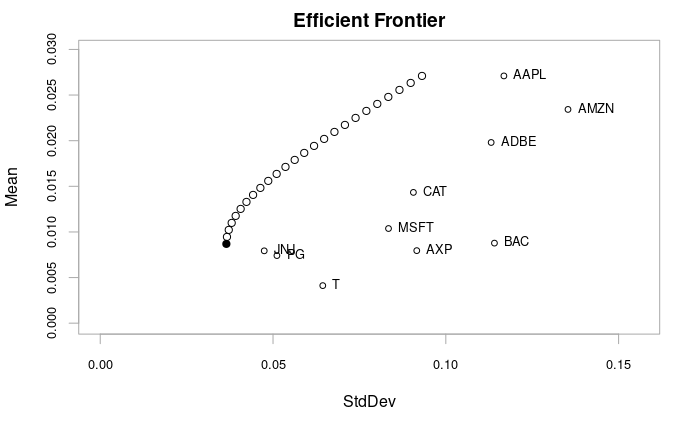

```r
chart.EfficientFrontier(portf_minvaref, match.col = "StdDev", type = "b", rf = NULL, pch.assets = 1)
```

Now, we rebalance it with training period = 24 (2 years).

```r
bt_gmv <- optimize.portfolio.rebalancing(R=R,portfolio=portf_minvar,
                                         optimize_method="ROI",
                                         rebalance_on="months",
                                         training_period=24)
bt_gmv
```

```
PortfolioAnalytics Optimization with Rebalancing

Call:
optimize.portfolio.rebalancing(R = R, portfolio = portf_minvar,
    optimize_method = "ROI", rebalance_on = "months", training_period = 24)

Number of rebalancing dates:  226
First rebalance date:
[1] "2001-12-31"
Last rebalance date:
[1] "2020-09-29"

Annualized Portfolio Rebalancing Return:
[1] 0.08543629

Annualized Portfolio Standard Deviation:
[1] 0.1382772
```

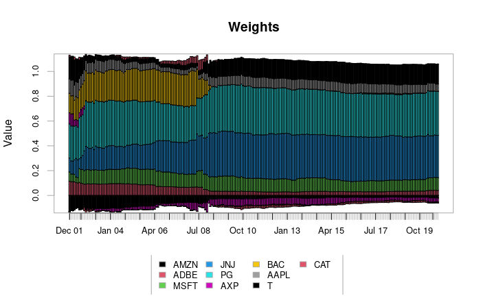

```r
chart.Weights(bt_gmv)
```

```r
returns_gmv <- Return.portfolio(R = R, weights = extractWeights(bt_gmv))
```

#### Mininum Variance Portfolio with Long Only Constraint.

Now, we add the long only constraint - we do not allow for short selling.

```r
portf_minvar_2 <- portfolio.spec(assets=stockselection)
portf_minvar_2 <- add.constraint(portfolio=portf_minvar_2, type="box",
                               min=0, max=1)
portf_minvar_2 <- add.objective(portfolio=portf_minvar_2, type="risk", name="var")
portf_minvar_2
```

```
PortfolioAnalytics Portfolio Specification

Call:
portfolio.spec(assets = stockselection)

Number of assets: 10
Asset Names
 [1] "AMZN" "ADBE" "MSFT" "JNJ"  "PG"   "AXP"  "BAC"  "AAPL" "T"    "CAT"

Constraints
Enabled constraint types
        - box (long only)

Objectives:
Enabled objective names
        - var
```

Next, we run the optimization.

```r
opt_minvar_2 <- optimize.portfolio(R=R, portfolio=portf_minvar_2,
                                 optimize_method="ROI", trace=TRUE)
print(opt_minvar_2)
```

```
PortfolioAnalytics Optimization

Call:
optimize.portfolio(R = R, portfolio = portf_minvar_2, optimize_method = "ROI",
    trace = TRUE)

Optimal Weights:
  AMZN   ADBE   MSFT    JNJ     PG    AXP    BAC   AAPL      T    CAT
0.0000 0.0276 0.0885 0.3344 0.3409 0.0000 0.0000 0.0517 0.1569 0.0000

Objective Measure:
 StdDev
0.03669
```

We plot the efficient frontier (long only) to compare it with the first plot which has the full investment constraint.

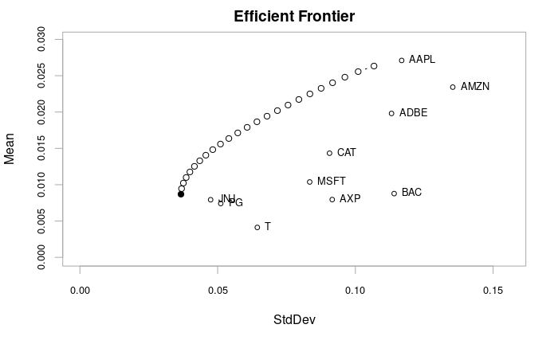

```r
portf_minvaref_2 <- create.EfficientFrontier(R=R, portfolio = portf_minvar_2, type = "mean-StdDev", match.col = "StdDev")
chart.EfficientFrontier(portf_minvaref_2, match.col = "StdDev", type = "b", rf = NULL, pch.assets = 1)
```

Now, we rebalance it with training period = 24 (2 years).

```r
bt_minvar_2 <- optimize.portfolio.rebalancing(R=R, portfolio=portf_minvar_2,
                                            optimize_method="ROI",
                                            rebalance_on="months",
                                            training_period=24)

bt_minvar_2
```

```
PortfolioAnalytics Optimization with Rebalancing

Call:
optimize.portfolio.rebalancing(R = R, portfolio = portf_minvar_2,
    optimize_method = "ROI", rebalance_on = "months", training_period = 24)

Number of rebalancing dates:  226
First rebalance date:
[1] "2001-12-31"
Last rebalance date:
[1] "2020-09-29"

Annualized Portfolio Rebalancing Return:
[1] 0.09646748

Annualized Portfolio Standard Deviation:
[1] 0.1341246
```

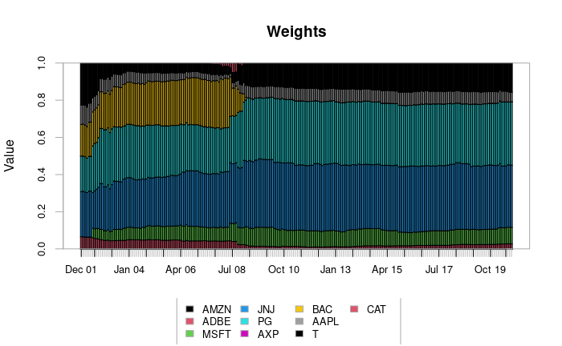

```r
chart.Weights(bt_minvar_2)
```

```r
returns_minvar <- Return.portfolio(R = R, weights = extractWeights(bt_minvar_2))
```

#### Mininum Variance Portfolio Group Constraint.

Our stocks: “AMZN”,“ADBE”,“MSFT”,“JNJ”,“PG”,“AXP”,“BAC”,“AAPL”,“T”,“CAT”

Grouped as follows: Group A: AMZN, ADBE, BAC, AAPL, T Group B: MSFT, CAT Group C: JNJ, PG, AXP

We tell it to invest as follows in the groups Group A: 30% - 80% Group B: 20% - 70% Group C: 0% - 50% So the groups we created have to add up to the weight intervals we definded

```r
portf_minvar_3 <- portfolio.spec(assets=stockselection)
portf_minvar_3 <- add.constraint(portfolio=portf_minvar_3,
                               type="group",
                               groups=list(groupA=c(1,2,7,8,9),
                                           groupB=c(3,10),
                                           groupC=c(4,5,6)),
                               group_min=c(0.3, 0.2, 0),
                               group_max=c(0.8, 0.7, 0.5))
portf_minvar_3 <- add.objective(portfolio=portf_minvar_3, type="risk", name="var")
portf_minvar_3
```

```
PortfolioAnalytics Portfolio Specification

Call:
portfolio.spec(assets = stockselection)

Number of assets: 10
Asset Names
 [1] "AMZN" "ADBE" "MSFT" "JNJ"  "PG"   "AXP"  "BAC"  "AAPL" "T"    "CAT"

Constraints
Enabled constraint types
        - group

Objectives:
Enabled objective names
        - var
```

Next, we run the optimization.

```r
opt_minvar_3 <- optimize.portfolio(R=R, portfolio=portf_minvar_3,
                                 optimize_method="ROI", trace=TRUE)
print(opt_minvar_3)
```

```
PortfolioAnalytics Optimization

Call:
optimize.portfolio(R = R, portfolio = portf_minvar_3, optimize_method = "ROI",
    trace = TRUE)

Optimal Weights:
   AMZN    ADBE    MSFT     JNJ      PG     AXP     BAC    AAPL       T     CAT
-0.0198  0.0508  0.1417  0.2712  0.3243 -0.0955  0.0095  0.0539  0.2055  0.0583

Objective Measure:
 StdDev
0.03738
```

Next, we chart the efficient frontiers.

```r
portf_minvaref_3 <- create.EfficientFrontier(R=R, portfolio = portf_minvar_3, type = "mean-StdDev", match.col = "StdDev")
```

```
Inf or -Inf values detected in box constraints, maximum return
            objectives must have finite box constraint values.
```

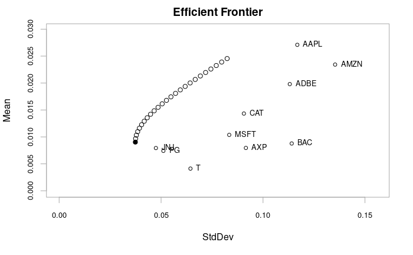

```r
chart.EfficientFrontier(portf_minvaref_3, match.col = "StdDev", type = "b", rf = NULL, pch.assets = 1)
```

Now, we rebalance it with training period = 24 (2 years).

```r
bt_minvar_3 <- optimize.portfolio.rebalancing(R=R, portfolio=portf_minvar_3,
                                            optimize_method="ROI",
                                            rebalance_on="months",
                                            training_period=24)

bt_minvar_3
```

```
PortfolioAnalytics Optimization with Rebalancing

Call:
optimize.portfolio.rebalancing(R = R, portfolio = portf_minvar_3,
    optimize_method = "ROI", rebalance_on = "months", training_period = 24)

Number of rebalancing dates:  226
First rebalance date:
[1] "2001-12-31"
Last rebalance date:
[1] "2020-09-29"

Annualized Portfolio Rebalancing Return:
[1] 0.08763507

Annualized Portfolio Standard Deviation:
[1] 0.1397948
```

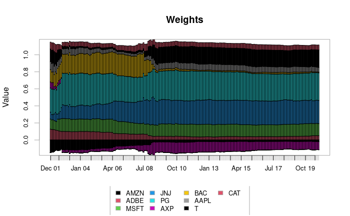

```r
chart.Weights(bt_minvar_3)
```

```r
returns_minvar <- Return.portfolio(R=R, weights=extractWeights(bt_minvar_3))
```

#### Mininum Variance Portfolio Group Constraint + box constraint.

```r
portf_minvar_4 <- portfolio.spec(assets=stockselection)
portf_minvar_4 <- add.constraint(portfolio=portf_minvar_4, type="box",
                               min=0, max=1)
portf_minvar_4 <- add.objective(portfolio=portf_minvar_4, type="risk", name="var")
portf_minvar_4 <- add.constraint(portfolio=portf_minvar_4,
                               type="group",
                               groups=list(groupA=c(1,2,7,8,9),
                                           groupB=c(3,10),
                                           groupC=c(4,5,6)),
                               group_min=c(0.3, 0.2, 0),
                               group_max=c(0.8, 0.7, 0.5))
portf_minvar_4
```

```
PortfolioAnalytics Portfolio Specification

Call:
portfolio.spec(assets = stockselection)

Number of assets: 10
Asset Names
 [1] "AMZN" "ADBE" "MSFT" "JNJ"  "PG"   "AXP"  "BAC"  "AAPL" "T"    "CAT"

Constraints
Enabled constraint types
        - box (long only)
        - group

Objectives:
Enabled objective names
        - var
```

Next, we run the optimization.

```r
opt_minvar_4 <- optimize.portfolio(R=R, portfolio=portf_minvar_4,
                                 optimize_method="ROI", trace=TRUE)
print(opt_minvar_4)
```

```
PortfolioAnalytics Optimization

Call:
optimize.portfolio(R = R, portfolio = portf_minvar_4, optimize_method = "ROI",
    trace = TRUE)

Optimal Weights:
  AMZN   ADBE   MSFT    JNJ     PG    AXP    BAC   AAPL      T    CAT
0.0000 0.0357 0.1533 0.2139 0.2861 0.0000 0.0000 0.0408 0.2235 0.0467

Objective Measure:
 StdDev
0.03827
```

Next, we chart the efficient frontiers.

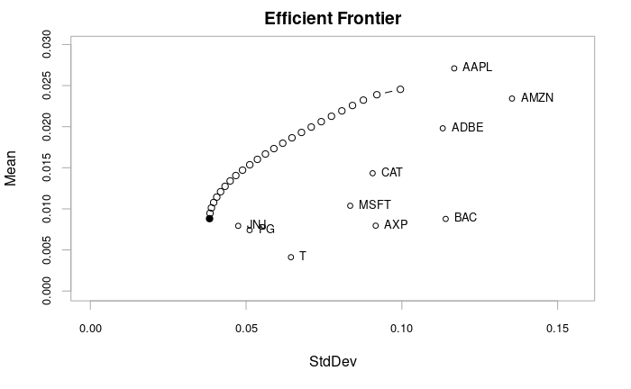

```r
portf_minvaref_4 <- create.EfficientFrontier(R=R, portfolio = portf_minvar_4, type = "mean-StdDev", match.col = "StdDev")
chart.EfficientFrontier(portf_minvaref_4, match.col = "StdDev", type = "b", rf = NULL, pch.assets = 1)
```

Now, we rebalance it with training period = 24 (2 years).

```r
bt_minvar_4 <- optimize.portfolio.rebalancing(R=R, portfolio=portf_minvar_4,
                                            optimize_method="ROI",
                                            rebalance_on="months",
                                            training_period=24)

bt_minvar_4
```

```
PortfolioAnalytics Optimization with Rebalancing

Call:
optimize.portfolio.rebalancing(R = R, portfolio = portf_minvar_4,
    optimize_method = "ROI", rebalance_on = "months", training_period = 24)

Number of rebalancing dates:  226
First rebalance date:
[1] "2001-12-31"
Last rebalance date:
[1] "2020-09-29"

Annualized Portfolio Rebalancing Return:
[1] 0.1000132

Annualized Portfolio Standard Deviation:
[1] 0.1378477
```

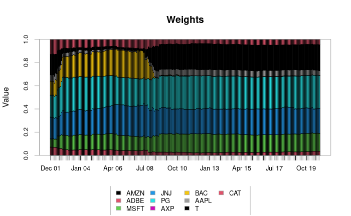

```r
chart.Weights(bt_minvar_4)
```

```r
returns_minvar <- Return.portfolio(R=R, weights=extractWeights(bt_minvar_4))
```

### plot of the weights minimum variance portfolios with our constraints

```r
print(opt_gmv)
```

```
PortfolioAnalytics Optimization

Call:
optimize.portfolio(R = R, portfolio = portf_minvar, optimize_method = "ROI",
    trace = TRUE)

Optimal Weights:
   AMZN    ADBE    MSFT     JNJ      PG     AXP     BAC    AAPL       T     CAT
-0.0200  0.0416  0.1026  0.3405  0.3558 -0.0328 -0.0077  0.0580  0.1597  0.0024

Objective Measure:
StdDev
0.0365
```

```r
print(opt_minvar_2)
```

```
PortfolioAnalytics Optimization

Call:
optimize.portfolio(R = R, portfolio = portf_minvar_2, optimize_method = "ROI",
    trace = TRUE)

Optimal Weights:
  AMZN   ADBE   MSFT    JNJ     PG    AXP    BAC   AAPL      T    CAT
0.0000 0.0276 0.0885 0.3344 0.3409 0.0000 0.0000 0.0517 0.1569 0.0000

Objective Measure:
 StdDev
0.03669
```

```r
print(opt_minvar_3)
```

```
PortfolioAnalytics Optimization

Call:
optimize.portfolio(R = R, portfolio = portf_minvar_3, optimize_method = "ROI",
    trace = TRUE)

Optimal Weights:
   AMZN    ADBE    MSFT     JNJ      PG     AXP     BAC    AAPL       T     CAT
-0.0198  0.0508  0.1417  0.2712  0.3243 -0.0955  0.0095  0.0539  0.2055  0.0583

Objective Measure:
 StdDev
0.03738
```

```r
print(opt_minvar_4)
```

```
PortfolioAnalytics Optimization

Call:
optimize.portfolio(R = R, portfolio = portf_minvar_4, optimize_method = "ROI",
    trace = TRUE)

Optimal Weights:
  AMZN   ADBE   MSFT    JNJ     PG    AXP    BAC   AAPL      T    CAT
0.0000 0.0357 0.1533 0.2139 0.2861 0.0000 0.0000 0.0408 0.2235 0.0467

Objective Measure:
 StdDev
0.03827
```

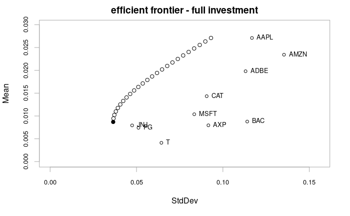

```r
chart.EfficientFrontier(portf_minvaref, match.col = "StdDev", type = "b", rf = NULL, pch.assets = 1,main="efficient frontier - full investment")
```

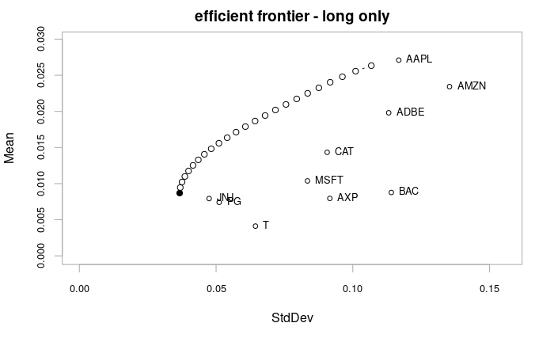

```r
chart.EfficientFrontier(portf_minvaref_2, match.col = "StdDev", type = "b", rf = NULL, pch.assets = 1, main="efficient frontier - long only")
```

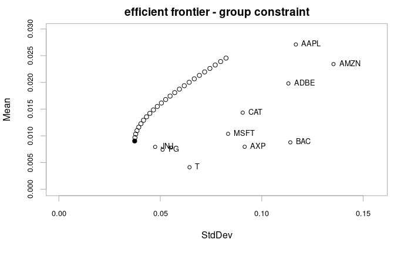

```r
chart.EfficientFrontier(portf_minvaref_3, match.col = "StdDev", type = "b", rf = NULL, pch.assets = 1, main="efficient frontier - group constraint")
```

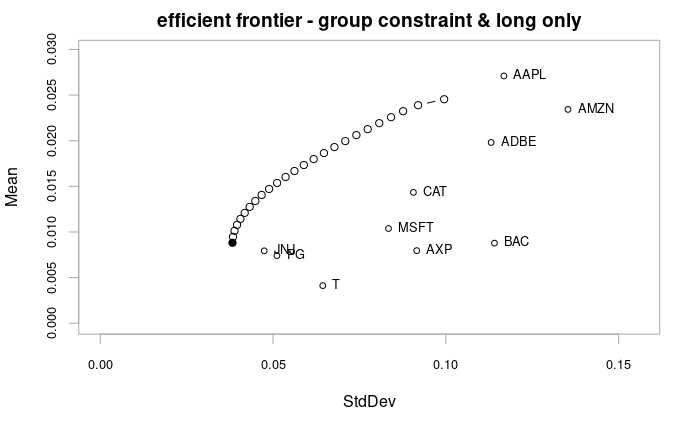

```r
chart.EfficientFrontier(portf_minvaref_4, match.col = "StdDev", type = "b", rf = NULL, pch.assets = 1, main="efficient frontier - group constraint & long only")
```

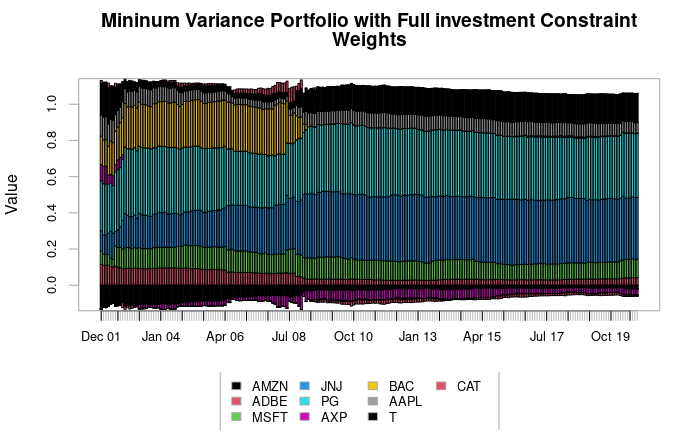

```r
chart.Weights(bt_gmv)
title(main = "Mininum Variance Portfolio with Full investment Constraint")
```

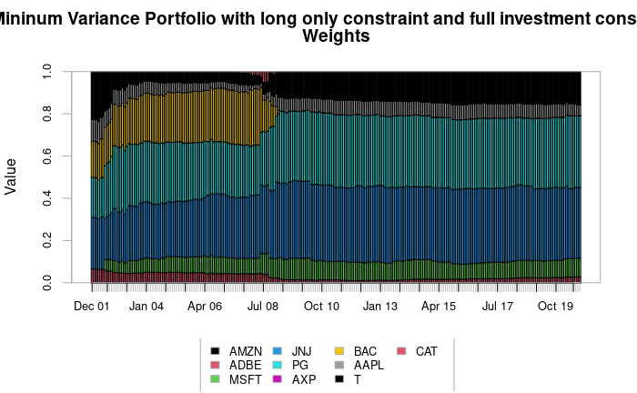

```r
chart.Weights(bt_minvar_2)
title(main = "Mininum Variance Portfolio with long only constraint and full investment constraint")
```

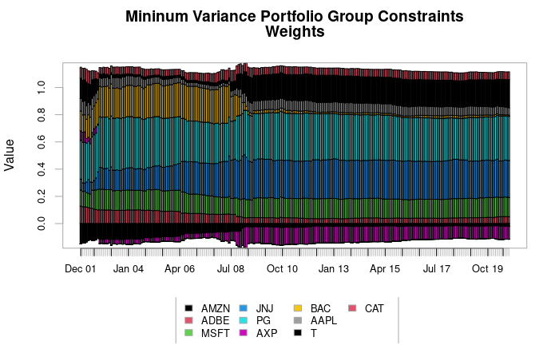

```r
chart.Weights(bt_minvar_3)
title(main = "Mininum Variance Portfolio Group Constraints")
```

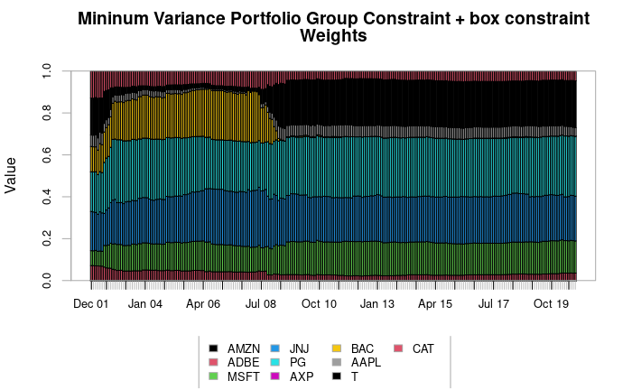

```r
chart.Weights(bt_minvar_4)
title(main = "Mininum Variance Portfolio Group Constraint + box constraint")
```

```r
chart.GroupWeights(bt_minvar_2)
```

[output not shown]

2. Maximum Quadratic Utility Portfolios

### Maximum Quadratic Utility Portfolio with full investment constraint (now we deleted it) and long only constraint

First, we create the initial portfolio object.

```r
init_portf <- portfolio.spec(assets=stockselection)
```

Then, we create our constraints and combine them in a list.

```r
lo_constr <- box_constraint(type="long_only", assets=init_portf$assets)
qu_constr <- list(lo_constr)
```

Next, we create the objective. The variance objective specifies a risk aversion parameter which defines how much variance is accepted. After that, we combine these objectives in a list.

```r
ret_obj <- return_objective(name="mean")

var_obj <- portfolio_risk_objective(name="var", risk_aversion=2.00)
qu_obj <- list(ret_obj, var_obj)
```

Next, we run the optimization.

```r
opt_qu <- optimize.portfolio(R=R, portfolio=init_portf,
                             constraints=qu_constr,
                             objectives=qu_obj,
                             optimize_method="ROI",
                             trace=TRUE)
opt_qu
```

```
PortfolioAnalytics Optimization

Call:
optimize.portfolio(R = R, portfolio = init_portf, constraints = qu_constr,
    objectives = qu_obj, optimize_method = "ROI", trace = TRUE)

Optimal Weights:
  AMZN   ADBE   MSFT    JNJ     PG    AXP    BAC   AAPL      T    CAT
0.0840 0.0917 0.0000 0.1757 0.2267 0.0000 0.0000 0.3337 0.0000 0.0883

Objective Measure:
   mean
0.01716


 StdDev
0.05747
```

```r
bt_qu <- optimize.portfolio.rebalancing(R=R, portfolio=init_portf,
                                        constraints=qu_constr,
                                        objectives=qu_obj,
                                        optimize_method="ROI",
                                        rebalance_on="months",
                                        training_period=24)
print(bt_qu)
```

```
PortfolioAnalytics Optimization with Rebalancing

Call:
optimize.portfolio.rebalancing(R = R, portfolio = init_portf,
    constraints = qu_constr, objectives = qu_obj, optimize_method = "ROI",
    rebalance_on = "months", training_period = 24)

Number of rebalancing dates:  226
First rebalance date:
[1] "2001-12-31"
Last rebalance date:
[1] "2020-09-29"

Annualized Portfolio Rebalancing Return:
[1] 0.1390139

Annualized Portfolio Standard Deviation:
[1] 0.1681174
```

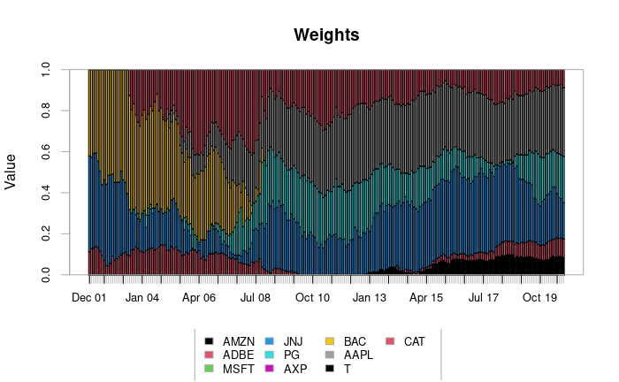

```r
chart.Weights(bt_qu)
```

```r
returns_qu <- Return.portfolio(R = R, weights = extractWeights(bt_qu))
```

### Maximum Quadratic Utility Portfolio with group constraint

Our stocks: “AMZN”,“ADBE”,“MSFT”,“JNJ”,“PG”,“AXP”,“BAC”,“AAPL”,“T”,“CAT”

Grouped as follows: Group A: AMZN, ADBE, BAC, AAPL, T Group B: MSFT, CAT Group C: JNJ, PG, AXP

We tell it to invest as follows in the groups Group A: 30% - 80% Group B: 20% - 70% Group C: 0% - 50% So the groups we created have to add up to the weight intervals we defined.

We create our second portfolio object.

```r
init_portf_2 <- portfolio.spec(assets=stockselection)
```

Now, we add the constraint and combine them in a list.

```r
group_constr <- group_constraint(assets=stockselection,groups=list(groupA=c(1,2,7,8,9), groupB=c(3,10),groupC=c(4,5,6)),group_min=c(0.3, 0.2, 0),group_max=c(0.8, 0.7, 0.5))
qu_constr_2 <- list(group_constr)
```

Next, we create the return objectives. We use the same as before.

```r
ret_obj <- return_objective(name="mean")
var_obj <- portfolio_risk_objective(name="var", risk_aversion=2.00)
qu_obj <- list(ret_obj, var_obj)
```

Now, we run the optimization.

```r
opt_qu_2 <- optimize.portfolio(R=R, portfolio=init_portf_2,
                             constraints=qu_constr_2,
                             objectives=qu_obj,
                             optimize_method="ROI",
                             trace=TRUE)
opt_qu_2
```

[output not shown]

Now, we rebalance it with training period = 24 (2 years).

```r
bt_qu_2 <- optimize.portfolio.rebalancing(R=R, portfolio=init_portf_2,
                                        constraints=qu_constr_2,
                                        objectives=qu_obj,
                                        optimize_method="ROI",
                                        rebalance_on="months",
                                        training_period=24)
print(bt_qu_2)
```

```
PortfolioAnalytics Optimization with Rebalancing

Call:
optimize.portfolio.rebalancing(R = R, portfolio = init_portf_2,
    constraints = qu_constr_2, objectives = qu_obj, optimize_method = "ROI",
    rebalance_on = "months", training_period = 24)

Number of rebalancing dates:  226
First rebalance date:
[1] "2001-12-31"
Last rebalance date:
[1] "2020-09-29"

Annualized Portfolio Rebalancing Return:
[1] 0.06149332

Annualized Portfolio Standard Deviation:
[1] 0.2939873
```

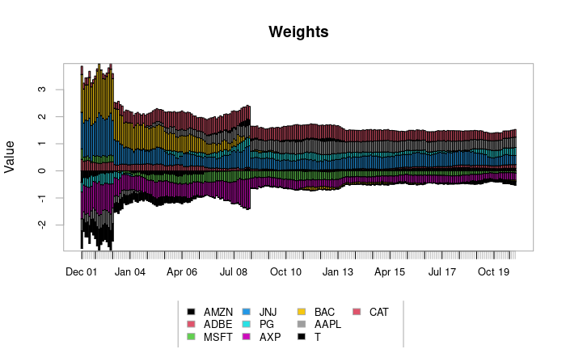

```r
chart.Weights(bt_qu_2)
```

```r
returns_qu_2 <- Return.portfolio(R = R, weights = extractWeights(bt_qu_2))
```

### Maximum Quadratic Utility Portfolio with traget return constraint

We create our second portfolio object.

```r
init_portf_3 <- portfolio.spec(assets=stockselection)
```

Now, we add the constraint and combine them in a list.

```r
ret_constr <- return_constraint(return_target=0.007)
qu_constr_3 <- list(ret_constr)
```

Next, we create the return objectives. We use the same as before.

```r
ret_obj <- return_objective(name="mean")
var_obj <- portfolio_risk_objective(name="var", risk_aversion=2.00)
qu_obj <- list(ret_obj, var_obj)
```

Now, we run the optimization. As we can see, our mean is exactly what we wanted it to be - 0.007.

```r
opt_qu_3 <- optimize.portfolio(R=R, portfolio=init_portf_3,
                             constraints=qu_constr_3,
                             objectives=qu_obj,
                             optimize_method="ROI",
                             trace=TRUE)
opt_qu_3
```

```
PortfolioAnalytics Optimization

Call:
optimize.portfolio(R = R, portfolio = init_portf_3, constraints = qu_constr_3,
    objectives = qu_obj, optimize_method = "ROI", trace = TRUE)

Optimal Weights:
   AMZN    ADBE    MSFT     JNJ      PG     AXP     BAC    AAPL       T     CAT
-0.0382  0.0272  0.1363  0.3394  0.3646 -0.0008 -0.0030  0.0089  0.1990 -0.0333

Objective Measure:
 mean
0.007


 StdDev
0.03733
```

Now, we rebalance it with training period = 24 (2 years).

```r
bt_qu_3 <- optimize.portfolio.rebalancing(R=R, portfolio=init_portf_3,
                                        constraints=qu_constr_3,
                                        objectives=qu_obj,
                                        optimize_method="ROI",
                                        rebalance_on="months",
                                        training_period=24)
print(bt_qu_3)
```

```
PortfolioAnalytics Optimization with Rebalancing

Call:
optimize.portfolio.rebalancing(R = R, portfolio = init_portf_3,
    constraints = qu_constr_3, objectives = qu_obj, optimize_method = "ROI",
    rebalance_on = "months", training_period = 24)

Number of rebalancing dates:  226
First rebalance date:
[1] "2001-12-31"
Last rebalance date:
[1] "2020-09-29"

Annualized Portfolio Rebalancing Return:
[1] 0.08002021

Annualized Portfolio Standard Deviation:
[1] 0.1373578
```

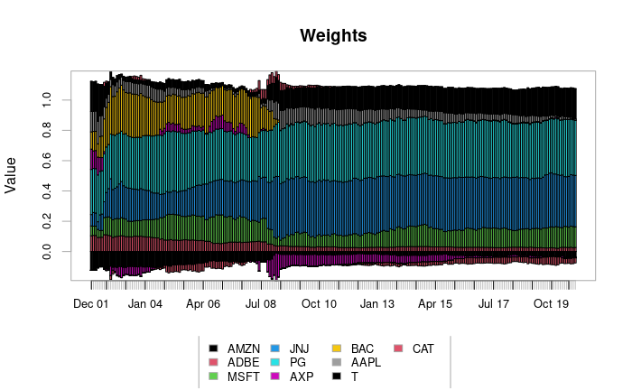

```r
chart.Weights(bt_qu_3)
```

```r
returns_qu_3 <- Return.portfolio(R = R, weights = extractWeights(bt_qu_3))
```

### Maximum Quadratic Utility Portfolio with Factor Exposure Constraint

The factor exposure constraint allows the user to set upper and lower bounds on exposures to risk factors. The exposures can be passed in as a vector or matrix. Here we specify a vector for B with arbitrary values, e.g. betas of the assets, with a market risk exposure range of 0.6 to 0.9.

We create our second portfolio object.

```r
init_portf_4 <- portfolio.spec(assets=stockselection)
```

-“AMZN” = 1.35 -“ADBE” = 0.97 -“MSFT” = 0.92 -“JNJ” = 0.69 -“PG” = 0.41 -“AXP” = 1.13 -“BAC” = 1.55 -“AAPL” = 1.31 -“T” = 1 -“CAT” = 1.03

1.35, 0.97, 0.92, 0.69, 0.41, 1.13, 1.55, 1.31, 1, 1.03

Now, we add the constraint and combine them in a list.

```r
exp_constr <- factor_exposure_constraint(assets=stockselection,B=c(1.35, 0.97, 0.92, 0.69, 0.41, 1.13, 1.55, 1.31, 1, 1.03),lower=0.6, upper=0.9)
qu_constr_4 <- list(exp_constr)
```

Next, we create the return objectives. We use the same as before.

```r
ret_obj <- return_objective(name="mean")
var_obj <- portfolio_risk_objective(name="var", risk_aversion=2.00)
qu_obj <- list(ret_obj, var_obj)
```

Now, we run the optimization.

```r
opt_qu_4 <- optimize.portfolio(R=R, portfolio=init_portf_4,
                             constraints=qu_constr_4,
                             objectives=qu_obj,
                             optimize_method="ROI",
                             trace=TRUE)
opt_qu_4
```

```
PortfolioAnalytics Optimization

Call:
optimize.portfolio(R = R, portfolio = init_portf_4, constraints = qu_constr_4,
    objectives = qu_obj, optimize_method = "ROI", trace = TRUE)

Optimal Weights:
   AMZN    ADBE    MSFT     JNJ      PG     AXP     BAC    AAPL       T     CAT
 0.1041  0.1401 -0.1275  0.3479  0.2957 -0.2517 -0.0395  0.3935 -0.1088  0.2463

Objective Measure:
   mean
0.02023


 StdDev
0.06495
```

Now, we rebalance it with training period = 24 (2 years).

```r
bt_qu_4 <- optimize.portfolio.rebalancing(R=R, portfolio=init_portf_4,
                                        constraints=qu_constr_4,
                                        objectives=qu_obj,
                                        optimize_method="ROI",
                                        rebalance_on="months",
                                        training_period=24)
print(bt_qu_4)
```

```
PortfolioAnalytics Optimization with Rebalancing

Call:
optimize.portfolio.rebalancing(R = R, portfolio = init_portf_4,
    constraints = qu_constr_4, objectives = qu_obj, optimize_method = "ROI",
    rebalance_on = "months", training_period = 24)

Number of rebalancing dates:  226
First rebalance date:
[1] "2001-12-31"
Last rebalance date:
[1] "2020-09-29"

Annualized Portfolio Rebalancing Return:
[1] 0.03709525

Annualized Portfolio Standard Deviation:
[1] 0.3167216
```

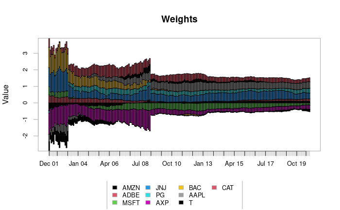

```r
chart.Weights(bt_qu_4)
```

```r
returns_qu_4 <- Return.portfolio(R = R, weights = extractWeights(bt_qu_4))
```

### plots of the maximum quadratic utility portfolios

```r
opt_qu
```

```
PortfolioAnalytics Optimization

Call:
optimize.portfolio(R = R, portfolio = init_portf, constraints = qu_constr,
    objectives = qu_obj, optimize_method = "ROI", trace = TRUE)

Optimal Weights:
  AMZN   ADBE   MSFT    JNJ     PG    AXP    BAC   AAPL      T    CAT
0.0840 0.0917 0.0000 0.1757 0.2267 0.0000 0.0000 0.3337 0.0000 0.0883

Objective Measure:
   mean
0.01716


 StdDev
0.05747
```

```r
opt_qu_2
```

```
PortfolioAnalytics Optimization

Call:
optimize.portfolio(R = R, portfolio = init_portf_2, constraints = qu_constr_2,
    objectives = qu_obj, optimize_method = "ROI", trace = TRUE)

Optimal Weights:
   AMZN    ADBE    MSFT     JNJ      PG     AXP     BAC    AAPL       T     CAT
 0.0942  0.1389 -0.0832  0.3335  0.2995 -0.2622 -0.0509  0.3805 -0.1334  0.2832

Objective Measure:
   mean
0.02024


 StdDev
0.06511
```

```r
opt_qu_3
```

```
PortfolioAnalytics Optimization

Call:
optimize.portfolio(R = R, portfolio = init_portf_3, constraints = qu_constr_3,
    objectives = qu_obj, optimize_method = "ROI", trace = TRUE)

Optimal Weights:
   AMZN    ADBE    MSFT     JNJ      PG     AXP     BAC    AAPL       T     CAT
-0.0382  0.0272  0.1363  0.3394  0.3646 -0.0008 -0.0030  0.0089  0.1990 -0.0333

Objective Measure:
 mean
0.007


 StdDev
0.03733
```

```r
opt_qu_4
```

```
PortfolioAnalytics Optimization

Call:
optimize.portfolio(R = R, portfolio = init_portf_4, constraints = qu_constr_4,
    objectives = qu_obj, optimize_method = "ROI", trace = TRUE)

Optimal Weights:
   AMZN    ADBE    MSFT     JNJ      PG     AXP     BAC    AAPL       T     CAT
 0.1041  0.1401 -0.1275  0.3479  0.2957 -0.2517 -0.0395  0.3935 -0.1088  0.2463

Objective Measure:
   mean
0.02023


 StdDev
0.06495
```

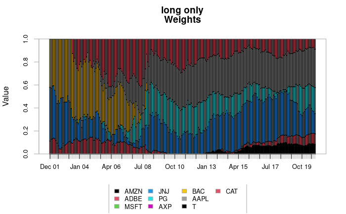

```r
chart.Weights(bt_qu)
title(main="long only")
```

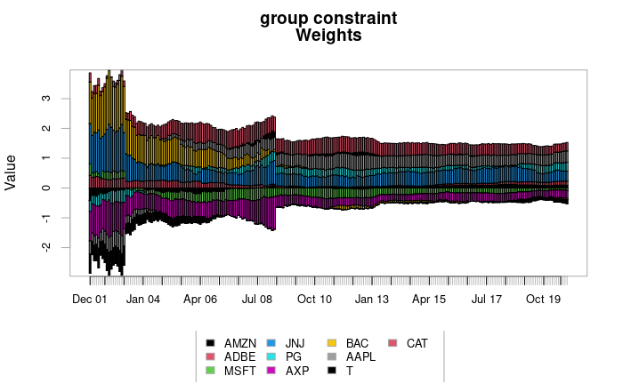

```r
chart.Weights(bt_qu_2)
title(main="group constraint")
```

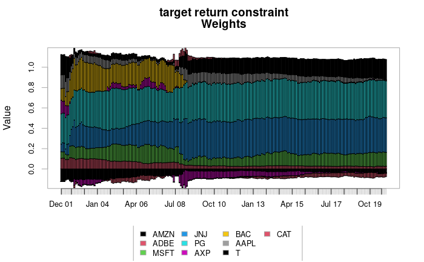

```r
chart.Weights(bt_qu_3)
title(main="target return constraint")
```

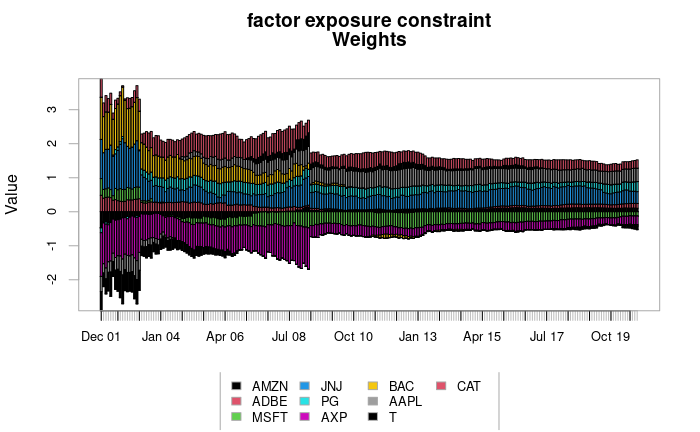

```r
chart.Weights(bt_qu_4)
title(main="factor exposure constraint")
```

### Constraints that do not work with ROI

- position limit constraints
- diversification constraint
- turnover constraint

## Exercise 2: Estimating the CAPM

In this exercise we want to estimate the CAPM. Please read carefully through the two documents provided (right hand side: files). Then we start to collect the necessary data:

In this exercise we want to estimate the CAPM. Please read carefully through the two documents provided (right hand side: files). Then we start to collect the necessary data:

1. From Datastream get the last 10 years of data from the 100 stocks of the S&P100 using the list `LS&P100I` (S&P 100): total return index (RI) and market cap (MV)

```r
library(readxl)
sp100_daily_RI <- read_excel("sp100 daily RI_2.xlsx")
head(sp100_daily_RI, n=10)
```

[output not shown]

2. Further import the Fama-French-Factors from Kenneth Frenchs homepage (monthly, e.g. using `FFdownload`). From both datasets we select data for the last (available) 60 months, calculate returns (simple percentage) for the US-Stocks and eliminate those stocks that have NAs for this period.

```r
# FF_worker because the sstoeckl/FFdownload had an issue in the converter (daily,..)
FF_worker <- function(output_file = "data.Rdata", tempdir=NULL) {

csv_files <- list.files(tempdir, full.names = TRUE, pattern = "\\.csv$", ignore.case = TRUE) # full path
csv_files2 <- list.files(tempdir, full.names = FALSE, pattern = "\\.csv$", ignore.case = TRUE) # only filenames

vars <- paste0("x_", gsub("(.*)\\..*", "\\1", csv_files2)  )

FF_worker <- mlply(function(y) converter(y), .data=csv_files, .progress = "text")
names(FF_worker) <- vars
save(FF_worker, file = output_file)
}
converter <- function(file) {
data <- readLines(file)

data[1] <- paste0(data[1],",")

index <- grep(",", data)
new_index <- sort(unique(c(index - 1, index)))

headers <- new_index[!(new_index %in% index)]
headers1 <- headers + 1
headers2 <- c(headers[-1] - 1,  max(new_index))
headers_names <- headers; headers_names[1] <- 1

l <- mapply(function(x, y) data[x:y], headers1, headers2, SIMPLIFY = FALSE)

names <- gsub("(.*) -- .*",  "\\1" , trimws(data[headers_names]))
names <- tolower(gsub(" ", "_", names))

if(any(names == "average_market_cap")) {
  other <- (which(names == "average_market_cap") + 1):length(headers)
  headers[other] <- paste0(headers[other] - 5, ":", headers[other])

  names <- vector()
  for(i in seq_along(headers)) names[i] <- gsub("(.*) -- .*",  "\\1" , paste0( trimws( data[eval(parse(text = headers[i]))]),collapse = "" ))
  names <- tolower(gsub(" ", "_", names))

}

if(any(names == "")){for (i in 1:length(names)){if(names[i]==""){names[i] <- paste0("Temp",i)}}}

names(l) <- names

datatest <- try(lapply(l[2:length(l)], function(x) na.omit(read.csv(text = x,  stringsAsFactors = FALSE, skip=0))), silent = TRUE)
if (class(datatest) == "try-error") {
  datatest <- lapply(l, function(x) na.omit(read.csv(text = x,  stringsAsFactors = FALSE, header = FALSE)))
}
datatest <- datatest[sapply(datatest, nrow) > 0]

d <- vector()
for (i in 1:length(datatest)) d[i] <- nchar(as.character(datatest[[i]]$X[1])) == 8
for (i in 1:length(datatest)) d[i] <- nchar(as.character(datatest[[i]][1,1])) == 8
m <- vector()
for (i in 1:length(datatest)) m[i] <- nchar(as.character(datatest[[i]]$X[1])) == 6
for (i in 1:length(datatest)) m[i] <- nchar(as.character(datatest[[i]][1,1])) == 6
a <- vector()
for (i in 1:length(datatest)) a[i] <- nchar(as.character(datatest[[i]]$X[1])) == 4
for (i in 1:length(datatest)) a[i] <- nchar(as.character(datatest[[i]][1,1])) == 4

annual  <- lapply(datatest[unlist(a)], function(x) xts::xts(as.data.frame(lapply(x[,-1,drop=FALSE],as.numeric)), order.by = as.yearmon(as.character(x[, 1]), format = "%Y")) )
monthly <- lapply(datatest[unlist(m)], function(x) xts::xts(as.data.frame(lapply(x[,-1,drop=FALSE],as.numeric)), order.by = as.yearmon(as.character(x[, 1]), format = "%Y%m")))

return(list(annual = annual, monthly = monthly))
}
```

download the four Fama-French factors including the risk-free rate.

```r
require(quantmod)
require(tidyquant)
require(tidyverse)
library(quantmod)
require(FFdownload)

# UNCOMMEND TO DOWNLOAD THE NEWEST DATA!
FFdownload(exclude_daily=TRUE,tempdir=tempdir(),download=TRUE,download_only=TRUE)
FF_worker(output_file = "FFdata.RData", tempdir=tempdir())
load(file = "FFdata.RData")
library(timetk)

factors <- FF_worker$`x_F-F_Research_Data_Factors`$monthly$Temp2 %>%
        tk_tbl(rename_index="date") %>% # make tibble
        mutate(date=as.Date(date, frac=1)) %>% # make proper month-end date format
        mutate(Mkt.RF=Mkt.RF/100, RF=RF/100, HML=HML/100, SMB=SMB/100)
        #gather(key=FFvar,value = price,-date) # gather into tidy format
```

From both datasets we select data for the last (available) 60 months, calculate returns (simple percentage) for the US-Stocks and eliminate those stocks that have NAs for this period.

```r
require(tidyquant)
require(timetk)

anyNA(sp100_daily_RI)
sp100_daily_RI_prices <- gather(sp100_daily_RI, key = symbol, value= prices, "AMAZON.COM":"CHARTER COMMS.CL.A")
anyNA(sp100_daily_RI_prices)
```

```r
sp100_returns_RI_60_long <- sp100_daily_RI_prices %>% mutate(prices = as.numeric(prices)) %>% group_by(symbol) %>%
 tq_transmute(select = prices,
              mutate_fun = periodReturn,
              period="monthly",
              type="arithmetic",
              col_rename = "Stock.returns") %>% ungroup() %>% mutate(date = as.yearmon(date))
anyNA(sp100_returns_RI_60_long)

sp100_returns_RI_60_long <- sp100_returns_RI_60_long[c(2,1,3)] %>% group_by(symbol)

fama_french <- factors %>%
   select(date, Mkt.RF, RF) %>% mutate(date = as.yearmon(date))
```

3. Now subtract the risk-free rate from all the stocks. Then estimate each stocks beta with the market: Regress all stock excess returns on the market excess return and save all betas (optimally use `mutate` and `map` in combination with `lm`). Estimate the mean-return for each stock and plot the return/beta-combinations. Create the security market line and include it in the plot! What do you find?

```r
library(tidyquant)
library(tidyverse)
library(PerformanceAnalytics)


joined_data <- left_join(sp100_returns_RI_60_long, fama_french, by= c("date"))

joined_data <- mutate(joined_data,
      monthly_ret_rf = Stock.returns - RF)

require(xts)
regr_fun <- function(data_xts) {
   lm(monthly_ret_rf ~ Mkt.RF, data = as_data_frame(data_xts)) %>%
       coef()
}

beta_alpha <- joined_data %>%
   tq_mutate(mutate_fun = rollapply,
             width      = 60,
             FUN        = regr_fun,
             by.column  = FALSE,
             col_rename = c("alpha", "beta"))

beta_alpha
```

[output not shown]

```r
beta_alpha_filter <- filter(beta_alpha, !is.na(alpha))
symbol_beta_alpha <- beta_alpha_filter %>%
   select(symbol, alpha, beta)
symbol_beta_alpha
```

```r
alpha <- beta_alpha %>%
   select(symbol, alpha)
```

```
Error in eval(lhs, parent, parent) : object 'beta_alpha' not found
```

```r
beta <- beta_alpha_filter %>%
   select(symbol, beta)
```

```
Error in eval(lhs, parent, parent) : object 'beta_alpha_filter' not found
```

```r
library(dplyr)
means_sp100_RI_60 <- joined_data %>%
   group_by(symbol) %>%
   summarize(mu = mean(monthly_ret_rf, na.rm=TRUE))
```

```
Error in eval(lhs, parent, parent) : object 'joined_data' not found
```

```r
mu.hat <- mutate(beta_alpha,
      mu_capm = beta * mean(Mkt.RF))
```

```
Error in is.data.frame(.data) : object 'beta_alpha' not found
```

4. In a next step (following both documents), we sort the stocks according to their beta and build ten value-weighted portfolios (with more or less the same number of stocks). Repeat a) for the ten portfolios. What do you observe?

```r
sp100_monthly_MV <- read_excel("sp100 monthly MV.xlsx")
head(sp100_monthly_MV, n=10)
```

| Date | AMAZON.COM | ABBOTT LABORATORIES | INTERNATIONAL BUS.MCHS. | ADOBE (NAS) | ALLSTATE ORD SHS | HONEYWELL INTL. | AMGEN | AMERICAN EXPRESS | AMERICAN INTL.GP. | COMCAST A | APPLE | BERKSHIRE HATHAWAY 'B' | VERIZON COMMUNICATIONS | BOEING | BRISTOL MYERS SQUIBB | FEDEX | CATERPILLAR | CELGENE | JP MORGAN CHASE & CO. | CISCO SYSTEMS | COCA COLA | COLGATE-PALM. | DANAHER | TARGET | MORGAN STANLEY | WALT DISNEY | BANK OF AMERICA | CITIGROUP | EMERSON ELECTRIC | … |
| --- | --- | --- | --- | --- | --- | --- | --- | --- | --- | --- | --- | --- | --- | --- | --- | --- | --- | --- | --- | --- | --- | --- | --- | --- | --- | --- | --- | --- | --- | --- |
| 2014-09-01 | 156648.6 | 63516.22 | 191836.9 | 35761.26 | 26649.77 | 74521.56 | 105873.9 | 93720.00 | 79991.00 | 117624.8 | 613756.2 | 166090.9 | 206515.3 | 91373.69 | 83972.81 | 41991.64 | 68479.13 | 75969.38 | 223608.0 | 128015.9 | 182980.6 | 59118.51 | 53679.39 | 38067.33 | 67362.69 | 154283.0 | 169200.1 | 156590.8 | 44680.48 | … |
| 2014-10-01 | 146983.9 | 62008.44 | 185234.7 | 33684.80 | 26355.06 | 71752.38 | 105641.9 | 89805.88 | 75567.63 | 113818.9 | 581805.8 | 165328.6 | 205120.6 | 89838.75 | 83817.94 | 44792.54 | 59092.95 | 74698.13 | 223431.4 | 128156.6 | 187454.3 | 59140.63 | 52256.97 | 39334.77 | 67919.94 | 150180.4 | 176877.2 | 154807.3 | 42851.98 | … |
| 2014-11-01 | 141550.3 | 65185.67 | 162660.5 | 34866.81 | 27145.71 | 74883.56 | 122893.8 | 94000.31 | 75315.19 | 119560.4 | 641613.4 | 171215.5 | 209104.4 | 89850.56 | 95877.25 | 47358.77 | 60673.02 | 85788.75 | 227580.9 | 125852.5 | 183132.4 | 61437.34 | 56194.21 | 39071.35 | 67941.38 | 157424.3 | 181609.3 | 161987.3 | 44746.34 | … |
| 2014-12-01 | 150940.0 | 66736.63 | 159869.7 | 36781.98 | 28357.88 | 76245.69 | 126583.1 | 95335.00 | 76197.19 | 121710.9 | 674867.1 | 180590.3 | 207610.5 | 94384.81 | 97950.75 | 50332.88 | 59934.43 | 90596.94 | 224291.3 | 141083.8 | 195133.9 | 63251.00 | 58372.59 | 46339.15 | 68704.81 | 157192.3 | 176571.1 | 161623.8 | 43480.06 | … |
| 2015-01-01 | 144312.8 | 67790.63 | 158996.0 | 36258.30 | 29364.50 | 78218.31 | 121060.4 | 95179.88 | 77064.13 | 123627.2 | 647361.0 | 182572.3 | 194370.9 | 92666.63 | 97917.56 | 49200.04 | 55482.41 | 89343.00 | 233935.8 | 142234.4 | 184928.3 | 63059.64 | 60365.54 | 48351.93 | 75698.00 | 159718.9 | 188140.9 | 163628.6 | 42732.43 | … |
| 2015-02-01 | 169253.9 | 68250.94 | 153268.0 | 35435.10 | 29528.80 | 78086.25 | 115899.9 | 84018.94 | 69427.88 | 114676.4 | 690989.3 | 178413.8 | 195221.0 | 104273.10 | 100109.40 | 48517.24 | 49002.49 | 94702.31 | 206809.4 | 137197.5 | 182168.8 | 62579.55 | 58978.05 | 47535.88 | 68035.00 | 156240.8 | 162585.7 | 144775.3 | 40406.36 | … |
| 2015-03-01 | 179091.9 | 71253.88 | 158622.3 | 39968.62 | 29557.95 | 81638.13 | 121137.0 | 83602.88 | 76375.94 | 127591.1 | 751916.1 | 180343.4 | 201456.0 | 107635.60 | 103549.90 | 50089.61 | 50311.82 | 96319.00 | 230297.8 | 154112.0 | 188718.8 | 64411.85 | 61734.34 | 49731.79 | 71632.44 | 179966.7 | 168418.1 | 162338.6 | 39967.83 | … |
| 2015-04-01 | 171940.3 | 68319.00 | 156749.9 | 37555.19 | 29148.96 | 80703.44 | 119068.1 | 80443.44 | 74211.00 | 121133.6 | 723724.5 | 176023.0 | 199519.4 | 104024.40 | 105952.90 | 47171.66 | 48074.14 | 91723.63 | 222479.6 | 139104.0 | 177710.2 | 62496.73 | 59326.91 | 52680.29 | 70912.81 | 179201.9 | 162119.3 | 156622.1 | 38295.93 | … |
| 2015-05-01 | 196922.4 | 69510.00 | 171018.7 | 38235.55 | 28610.44 | 80124.94 | 121925.4 | 78906.94 | 76990.19 | 123999.5 | 742884.6 | 175967.6 | 205596.4 | 100041.70 | 107786.60 | 48729.50 | 52745.25 | 87682.06 | 236062.2 | 148701.0 | 178314.4 | 61221.27 | 58385.00 | 50906.03 | 73895.69 | 187526.0 | 169188.8 | 163115.2 | 39650.53 | … |
| 2015-06-01 | 200671.1 | 72859.69 | 167581.9 | 39956.48 | 27371.13 | 81344.38 | 119393.6 | 80725.25 | 78243.56 | 124785.0 | 752015.8 | 175955.3 | 200742.9 | 97676.69 | 110820.40 | 49762.38 | 51634.42 | 90775.31 | 245228.5 | 148406.1 | 178445.0 | 60515.70 | 61483.95 | 50766.44 | 76003.56 | 188272.6 | 173809.8 | 165208.8 | 40258.69 | … |

```r
anyNA(sp100_monthly_MV)
```

```
[1] FALSE
```

```r
sp100_monthly_MV <- gather(sp100_monthly_MV, key = symbol, value= value, "AMAZON.COM":"CHARTER COMMS.CL.A")
anyNA(sp100_daily_RI_prices)
```

```
[1] FALSE
```

mean value

```r
mean_sp100_MV <- sp100_monthly_MV %>%
   group_by(symbol) %>%
   summarize(mean_value = mean(value, na.rm=TRUE))
```

```r
symbol_beta_alpha_value <- left_join(mean_sp100_MV, beta,  by= "symbol")
```

[output not shown]

```r
symbol_beta_alpha_value <- arrange(symbol_beta_alpha_value, beta)
```

```
Error in is.data.frame(df) : object 'symbol_beta_alpha_value' not found
```

create weights

```r
Portfolio1 <- symbol_beta_alpha_value[1:10,]
```

```
Error: object 'symbol_beta_alpha_value' not found
```

returns Portfolio

```r
sp100_returns_RI_60_wide <- sp100_returns_RI_60_long %>% spread(symbol, Stock.returns)

portfolio1_returns_wide <- sp100_returns_RI_60_wide[c("date", Portfolio1$symbol)]
```

```
Error in `[.tbl_df`(sp100_returns_RI_60_wide, c("date", Portfolio1$symbol)) :
  object 'Portfolio1' not found
```

```r
joined_data_portfolio <- left_join(allportfolio_returns, fama_french, by= c("date"))
```

```
Error in left_join(allportfolio_returns, fama_french, by = c("date")) :
  object 'allportfolio_returns' not found
```

```r
beta_alpha_portfolio_filter <- filter(beta_alpha_portfolio, !is.na(alpha))
```

```
Error in filter(beta_alpha_portfolio, !is.na(alpha)) :
  object 'beta_alpha_portfolio' not found
```

```r
alpha_portfolio <- beta_alpha_portfolio %>%
   select(Portfolio, alpha)
```

```
Error in eval(lhs, parent, parent) :
  object 'beta_alpha_portfolio' not found
```

```r
beta_portfolio <- beta_alpha_portfolio %>%
   select(Portfolio, beta)
```

```
Error in eval(lhs, parent, parent) :
  object 'beta_alpha_portfolio' not found
```

```r
means_Portfolio <- joined_data_portfolio %>%
   group_by(Portfolio) %>%
   summarize(mu = mean(monthly_ret_rf, na.rm=TRUE))
```

```
Error in eval(lhs, parent, parent) :
  object 'joined_data_portfolio' not found
```

```r
return_beta_portfolio <- left_join(means_Portfolio, beta_portfolio, by="Portfolio")
```

```
Error in left_join(means_Portfolio, beta_portfolio, by = "Portfolio") :
  object 'means_Portfolio' not found
```

5. In the third step you follow page 6-8 of the second document and estimate the second-pass regression with the market and then market & idiosyncratic risk. What do you observe? Present all your results in a similar fashion as in the document.

```r
require(xts)
regr_fun_residuals <- function(data_xts) {
   data_xts <- lm(monthly_ret_rf ~ Mkt.RF, data = as_data_frame(data_xts))
R <- summary(data_xts)$sigma^2
return(R)
}

residuals <- joined_data %>%
   tq_mutate(mutate_fun = rollapply,
             width      = 60,
             FUN        = regr_fun_residuals,
             by.column  = FALSE,
             col_rename = c("Residuals"))
```

```
Error in eval(lhs, parent, parent) : object 'joined_data' not found
```

```r
p
```

```
Error: object 'p' not found
```

```r
require(xts)
regr_fun_residuals <- function(data_xts) {
   data_xts <- lm(monthly_ret_rf ~ Mkt.RF, data = as_data_frame(data_xts))
R <- summary(data_xts)$sigma^2
return(R)
}

residuals_portfolio <- joined_data_portfolio %>%
   tq_mutate(mutate_fun = rollapply,
             width      = 60,
             FUN        = regr_fun_residuals,
             by.column  = FALSE,
             col_rename = c("Residuals"))
```

```
Error in eval(lhs, parent, parent) :
  object 'joined_data_portfolio' not found
```

```r
p_portfolio
```

## Exercise 3: Calculating and checking the CAPM cont.

As we have seen: the CAPM for small portfolios does not work very well, and so we start using portfolios that get rid of the idiosyncratic risk! Go to Kenneth French’s Homepage again and download the following datasets: “Portfolios Formed on Market Beta” (where we will use 10 monthly value weighted portfolios formed on beta) and “25 Portfolios Formed on Size and Market Beta” (same thing) as well as the market factor and rf (as before). Now we are going to check the CAPM like famous researchers have done it! We can use returns as they are in the files (simple returns)!

```r
#Download the Portfolios from Kenneth French's Homepage
portf_mkt_beta <- "https://mba.tuck.dartmouth.edu/pages/faculty/ken.french/ftp/Portfolios_Formed_on_BETA_CSV.zip"
 portf_mkt_beta_csv <- "Portfolios_Formed_on_BETA.csv"
 temp <- tempfile()
download.file(portf_mkt_beta, temp, quiet = TRUE)
portf_mkt_beta <- read_csv(unz(temp, portf_mkt_beta_csv), skip = 15, quote = "\",") %>%
  dplyr::rename(date = "X1") %>%
  mutate_at(vars(-date), as.numeric) %>%
  mutate(date = rollback(ymd(parse_date_time(date, "%Y%m") + months(1))))%>%
  filter(date >= first('1964-01-01') & date <= '2018-12-31')
```

[output not shown]

```r
#Download the market factor and rf (Fama/French 3 Research Factors)
mkt_factors <- "https://mba.tuck.dartmouth.edu/pages/faculty/ken.french/ftp/F-F_Research_Data_Factors_CSV.zip"
 mkt_factors_csv <- "F-F_Research_Data_Factors.CSV"
 temp <- tempfile()
download.file(mkt_factors, temp, quiet = TRUE)
mkt_factors <- read_csv(unz(temp, mkt_factors_csv), skip = 3, quote = "\",") %>%
  dplyr::rename(date = X1) %>%
  mutate_at(vars(-date), as.numeric) %>%
  mutate(date = rollback(ymd(parse_date_time(date, "%Y%m") + months(1)))) %>%
  filter(date >= first('1964-01-01') & date <= '2018-12-31')
```

[output not shown]

1. Subtract the risk-free rate from the first set of 10 portfolios (only sorted on beta) (Lo 10,., Hi 10) and estimate each stocks beta with the market. Estimate the mean-return for each stock and plot the return/beta-combinations. Create the security market line and include it in the plot! What do you find? (You can split the file in 2-3 different time blocks and see if something changes). * Now we are done with the first-pass regression.*

```r
#join data, substract Risk-Free-Rate
ten_portf <- portf_mkt_beta[1:660, -c(2:6)]
ten_portf_joined <- left_join(mkt_factors, ten_portf)
ten_portf_joined <- ten_portf_joined <- ten_portf_joined%>% dplyr::rename("Lo10" = "Lo 10") %>% dplyr::rename("Dec2" = "Dec 2") %>% dplyr::rename("Dec3" = "Dec 3") %>% dplyr::rename("Dec4" = "Dec 4") %>% dplyr::rename("Dec5" = "Dec 5") %>% dplyr::rename("Dec6" = "Dec 6") %>% dplyr::rename("Dec7" = "Dec 7") %>% dplyr::rename("Dec8" = "Dec 8") %>% dplyr::rename("Dec9" = "Dec 9") %>% dplyr::rename("Hi10" = "Hi 10")
ten_portf_rf <- mutate(ten_portf_joined, Lo10rf = Lo10 - RF, Dec2rf = Dec2 - RF, Dec3rf = Dec3 - RF, Dec4rf = Dec4 - RF, Dec5rf = Dec5 -RF, Dec6rf = Dec6 - RF, Dec7rf = Dec7 - RF, Dec8rf = Dec8 - RF, De9rf = Dec9 - RF, Hi10rf = Hi10 - RF)
ten_portf_rf <- ten_portf_rf[-2:-15]

#Create XTS
mkt_factors_xts <- tk_xts(data = mkt_factors, date_var = date)
```

```
Non-numeric columns being dropped: date
```

```r
ten_portf_rf_xts <- ten_portf_rf %>%
  tk_xts(date_var = date, silent = TRUE)

#Calculate Betas for each portfolio
betas_ten_portf_lm <- lm(ten_portf_rf_xts ~ mkt_factors_xts[, 1])
betas_ten_portf_lm
```

```
Call:
lm(formula = ten_portf_rf_xts ~ mkt_factors_xts[, 1])

Coefficients:
                      Lo10rf    Dec2rf    Dec3rf    Dec4rf    Dec5rf    Dec6rf    Dec7rf    Dec8rf    De9rf     Hi10rf
(Intercept)            0.22686   0.13400   0.13708   0.15941   0.01401   0.05810  -0.09485  -0.01485  -0.10582  -0.23762
mkt_factors_xts[, 1]   0.61277   0.73631   0.83529   0.97332   1.01900   1.08292   1.15586   1.27900   1.38701   1.61138
```

```r
betas_ten_portf <- CAPM.beta(Ra = ten_portf_rf_xts, Rb = mkt_factors_xts[, 1], Rf = 0)
betas_ten_portf
```

```
              Lo10rf   Dec2rf    Dec3rf    Dec4rf   Dec5rf   Dec6rf   Dec7rf   Dec8rf    De9rf   Hi10rf
Beta: Mkt-RF 0.61277 0.736314 0.8352903 0.9733161 1.018999 1.082922 1.155863 1.278999 1.387011 1.611385
```

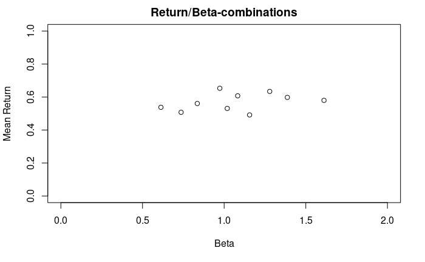

```r
#Estimate Mean Return
mean_ten_portf_rf_xts <- lapply(ten_portf_rf_xts, FUN=mean)
mean_ten_portf_rf_xts <- as.data.frame(mean_ten_portf_rf_xts)

#Plot the return/beta-combinations
plot.default(x = betas_ten_portf, xlim=c(0, 2),
             y = mean_ten_portf_rf_xts, ylim=c(0, 1),
             xlab = "Beta", ylab = "Mean Return",
             main = "Return/Beta-combinations")
```

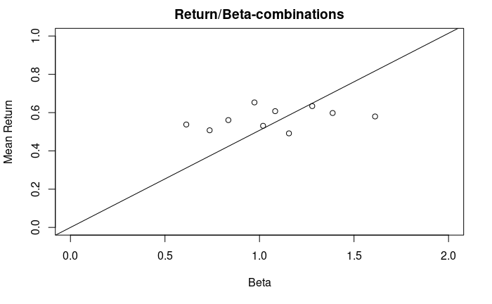

```r
mean_mkt <- lapply(mkt_factors_xts[, 1], FUN=mean)
mean_mkt <- as.data.frame(mean_mkt)
y_mkt <- mean_mkt[1, 1]
plot.default(x = betas_ten_portf, xlim=c(0, 2),
             y = mean_ten_portf_rf_xts, ylim=c(0, 1),
             xlab = "Beta", ylab = "Mean Return",
             main = "Return/Beta-combinations",
             abline(0, y_mkt))
```

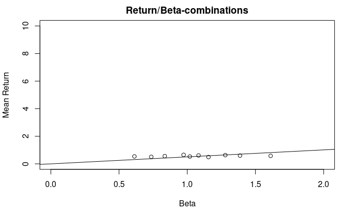

```r
plot.default(x = betas_ten_portf, xlim=c(0, 2),
             y = mean_ten_portf_rf_xts, ylim=c(0, 10),
             xlab = "Beta", ylab = "Mean Return",
             main = "Return/Beta-combinations",
             abline(0, y_mkt))
```

```r
#summary
summary_CAPM_ten_portf <- (table.CAPM(Ra = ten_portf_rf_xts, Rb = mkt_factors_xts[, 1], Rf = 0)[1:9, ])
```

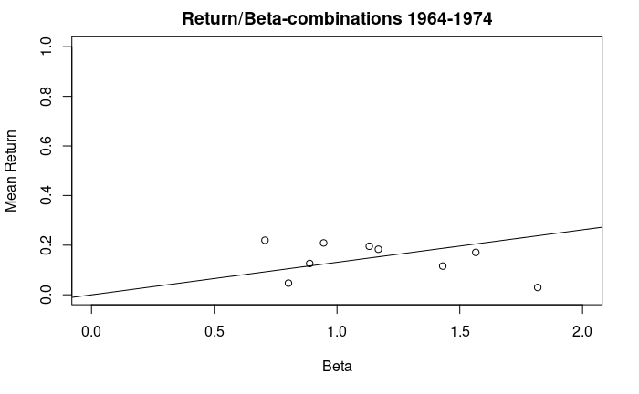

```r
#look for first 10 years
ten_portf_rf_10yrs_xts <- ten_portf_rf[1:120, ] %>%
  tk_xts(date_var = date, silent = TRUE)
betas_ten_portf_rf_10yrs <- CAPM.beta(Ra = ten_portf_rf_10yrs_xts, Rb = mkt_factors_xts[1:120, 1], Rf = 0)
mean_ten_portf_rf_10yrs_xts <- lapply(ten_portf_rf_10yrs_xts, FUN=mean)
mean_ten_portf_rf_10yrs_xts <- as.data.frame(mean_ten_portf_rf_10yrs_xts)
mean_mkt_10yrs <- lapply(mkt_factors_xts[1:120, 1], FUN=mean)
mean_mkt_10yrs <- as.data.frame(mean_mkt_10yrs)
y_mkt_10yrs <- mean_mkt_10yrs[1, 1]
plot.default(x = betas_ten_portf_rf_10yrs, xlim=c(0, 2),
             y = mean_ten_portf_rf_10yrs_xts, ylim=c(0, 1),
             xlab = "Beta", ylab = "Mean Return",
             main = "Return/Beta-combinations 1964-1974",
             abline(0, y_mkt_10yrs))
```

```r
summary_CAPM_ten_portf_10yrs <- (table.CAPM(Ra = ten_portf_rf_xts[1:120, ], Rb = mkt_factors_xts[1:120, 1], Rf = 0)[1:9, ])
summary_CAPM_ten_portf_10yrs
```

|  | Lo10rf to Mkt-RF | Dec2rf to Mkt-RF | Dec3rf to Mkt-RF | Dec4rf to Mkt-RF | Dec5rf to Mkt-RF | Dec6rf to Mkt-RF | Dec7rf to Mkt-RF | Dec8rf to Mkt-RF | De9rf to Mkt-RF | Hi10rf to Mkt-RF |
| --- | --- | --- | --- | --- | --- | --- | --- | --- | --- | --- |
| Alpha | 0.1272 | -0.0582 | 0.0095 | 0.0851 | 0.0475 | 0.0305 | -0.2370 | -0.0718 | -0.0342 | -0.2087 |
| Beta | 0.7065 | 0.8023 | 0.8886 | 0.9455 | 1.1314 | 1.1685 | 1.2601 | 1.4307 | 1.5652 | 1.8175 |
| Beta+ | 0.6189 | 0.7279 | 0.9062 | 1.0647 | 1.1989 | 1.1778 | 1.3302 | 1.4950 | 1.4848 | 1.7092 |
| Beta- | 0.8591 | 0.8510 | 0.8854 | 0.7909 | 1.1856 | 1.1260 | 1.1400 | 1.3138 | 1.5166 | 1.8216 |
| R-squared | 0.7237 | 0.8643 | 0.8675 | 0.8762 | 0.9066 | 0.8836 | 0.9002 | 0.8756 | 0.8576 | 0.7741 |
| Annualized Alpha | 3.2073 | -0.5129 | 0.1202 | 1.6658 | 0.7443 | 0.4343 | -0.9611 | -0.5908 | -0.3414 | -0.9397 |
| Correlation | 0.8507 | 0.9297 | 0.9314 | 0.9360 | 0.9521 | 0.9400 | 0.9488 | 0.9357 | 0.9261 | 0.8798 |
| Correlation p-value | 0.0000 | 0.0000 | 0.0000 | 0.0000 | 0.0000 | 0.0000 | 0.0000 | 0.0000 | 0.0000 | 0.0000 |
| Tracking Error | 7.1281 | 5.0726 | 4.9418 | 4.8729 | 5.2347 | 6.1848 | 6.6890 | 9.3535 | 11.5483 | 17.3136 |

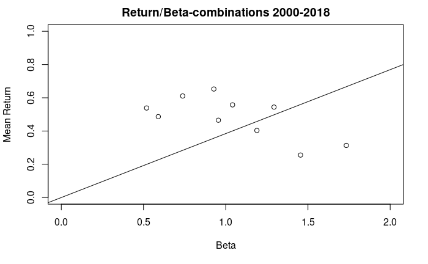

```r
#look for 2000-2018
ten_portf_rf_2000_xts <- ten_portf_rf[433:660, ] %>%
  tk_xts(date_var = date, silent = TRUE)
betas_ten_portf_rf_2000 <- CAPM.beta(Ra = ten_portf_rf_2000_xts, Rb = mkt_factors_xts[433:660, 1], Rf = 0)
mean_ten_portf_rf_2000_xts <- lapply(ten_portf_rf_2000_xts, FUN=mean)
mean_ten_portf_rf_2000_xts <- as.data.frame(mean_ten_portf_rf_2000_xts)
mean_mkt_2000 <- lapply(mkt_factors_xts[433:660, 1], FUN=mean)
mean_mkt_2000 <- as.data.frame(mean_mkt_2000)
y_mkt_2000 <- mean_mkt_2000[1, 1]
plot.default(x = betas_ten_portf_rf_2000, xlim=c(0, 2),
             y = mean_ten_portf_rf_2000_xts, ylim=c(0, 1),
             xlab = "Beta", ylab = "Mean Return",
             main = "Return/Beta-combinations 2000-2018",
             abline(0, y_mkt_2000))
```

```r
summary_CAPM_ten_portf_2000 <- (table.CAPM(Ra = ten_portf_rf_xts[433:660, ], Rb = mkt_factors_xts[433:660, 1], Rf = 0)[1:9, ])
summary_CAPM_ten_portf_2000
```

|  | Lo10rf to Mkt-RF | Dec2rf to Mkt-RF | Dec3rf to Mkt-RF | Dec4rf to Mkt-RF | Dec5rf to Mkt-RF | Dec6rf to Mkt-RF | Dec7rf to Mkt-RF | Dec8rf to Mkt-RF | De9rf to Mkt-RF | Hi10rf to Mkt-RF |
| --- | --- | --- | --- | --- | --- | --- | --- | --- | --- | --- |
| Alpha | 0.3390 | 0.2595 | 0.3269 | 0.2959 | 0.0977 | 0.1567 | -0.0542 | 0.0464 | -0.3042 | -0.3533 |
| Beta | 0.5187 | 0.5898 | 0.7380 | 0.9276 | 0.9551 | 1.0413 | 1.1895 | 1.2936 | 1.4548 | 1.7330 |
| Beta+ | 0.5375 | 0.6562 | 0.7733 | 1.0277 | 1.0501 | 1.1130 | 1.2546 | 1.3294 | 1.5322 | 1.8301 |
| Beta- | 0.4944 | 0.5997 | 0.6947 | 0.8998 | 0.9069 | 1.0503 | 1.2612 | 1.2086 | 1.3145 | 1.5299 |
| R-squared | 0.4970 | 0.5567 | 0.7287 | 0.8185 | 0.8351 | 0.8409 | 0.8729 | 0.8716 | 0.8412 | 0.8289 |
| Annualized Alpha | 32.2177 | 14.9426 | 28.8025 | 21.4346 | 2.0594 | 4.7388 | -0.4874 | 0.7239 | -0.9871 | -0.9947 |
| Correlation | 0.7050 | 0.7461 | 0.8537 | 0.9047 | 0.9139 | 0.9170 | 0.9343 | 0.9336 | 0.9172 | 0.9104 |
| Correlation p-value | 0.0000 | 0.0000 | 0.0000 | 0.0000 | 0.0000 | 0.0000 | 0.0000 | 0.0000 | 0.0000 | 0.0000 |
| Tracking Error | 10.7007 | 10.0591 | 7.8527 | 6.6749 | 6.4326 | 6.8570 | 7.4132 | 8.6935 | 11.7369 | 16.2170 |

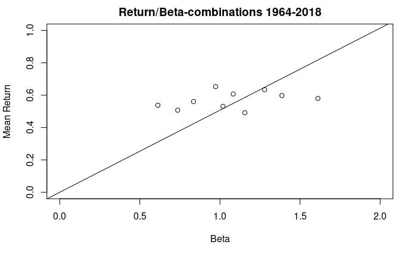

```r
plot.default(x = betas_ten_portf, xlim=c(0, 2),
             y = mean_ten_portf_rf_xts, ylim=c(0, 1),
             xlab = "Beta", ylab = "Mean Return",
             main = "Return/Beta-combinations 1964-2018",
             abline(0, y_mkt))
```

```r
NA
NA
NA
```

2. In the second-pass regression we now regress the average stock returns on the betas estimated before. What do you find in the coefficients and does this contradict the CAPM? Try different time periods again and see what you find. (all of the interpretations are in BKM pp.416f).
3. Now do the extended second pass regression (regress on betas and residual-sds that you can extract from the regression) and see what you find for different periods. Interpret according to concept check 13.2. One of the (many) problems of the CAPM can be the correlation between residual variances and betas. Calculate and interpret.

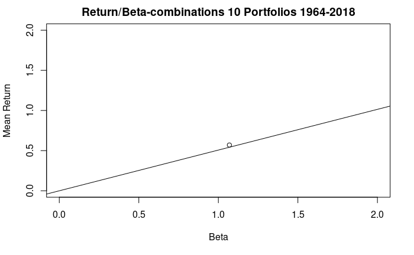

```r
#Look at a) -> We now do it with the mean return of every portfolio combined...

#1964-2018
com_mean_ten_portf_rf <- sum(mean_ten_portf_rf_xts)/10
mean_betas_ten_portf <- sum(betas_ten_portf)/10
plot.default(x = mean_betas_ten_portf, xlim=c(0, 2),
             y = com_mean_ten_portf_rf, ylim=c(0, 2),
             xlab = "Beta", ylab = "Mean Return",
             main = "Return/Beta-combinations 10 Portfolios 1964-2018",
             abline(0, y_mkt))
```

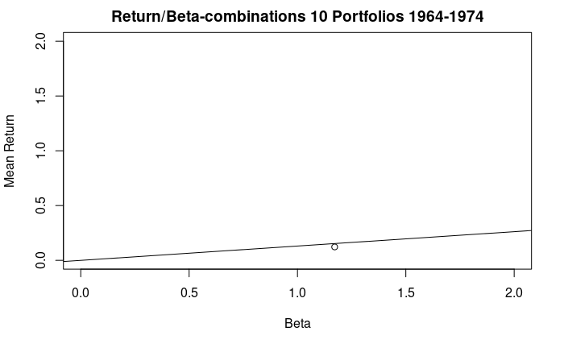

```r
#1964-1974
com_mean_ten_portf_rf_10yrs <- sum(mean_ten_portf_rf_10yrs_xts)/10
mean_betas_ten_portf_10yrs <- sum(betas_ten_portf_rf_10yrs)/10
plot.default(x = mean_betas_ten_portf_10yrs, xlim=c(0, 2),
             y = com_mean_ten_portf_rf_10yrs, ylim=c(0, 2),
             xlab = "Beta", ylab = "Mean Return",
             main = "Return/Beta-combinations 10 Portfolios 1964-1974",
             abline(0, y_mkt_10yrs))
```

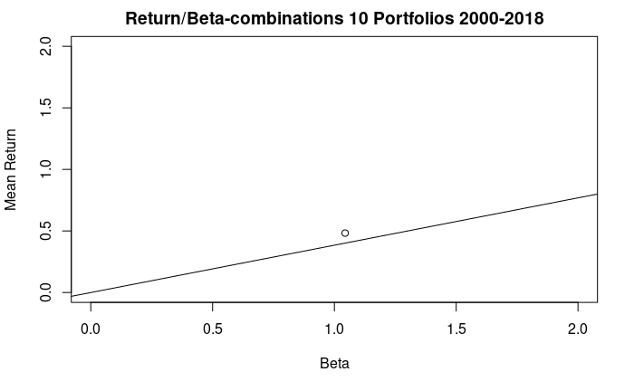

```r
#2000-2018
com_mean_ten_portf_rf_2000 <- sum(mean_ten_portf_rf_2000_xts)/10
mean_betas_ten_portf_2000 <- sum(betas_ten_portf_rf_2000)/10
plot.default(x = mean_betas_ten_portf_2000, xlim=c(0, 2),
             y = com_mean_ten_portf_rf_2000, ylim=c(0, 2),
             xlab = "Beta", ylab = "Mean Return",
             main = "Return/Beta-combinations 10 Portfolios 2000-2018",
             abline(0, y_mkt_2000))
```

```r
#SML-Function
calc_residual <- function(x) {y <- y_mkt*x}
calc_residual_10yrs <- function(x) {y <- y_mkt_10yrs*x}
calc_residual_2000 <- function(x) {y <- y_mkt_2000*x}
residual_1964_2018 <- as.data.frame((com_mean_ten_portf_rf - calc_residual(mean_betas_ten_portf))^2)
residual_1964_1974 <- as.data.frame((com_mean_ten_portf_rf_10yrs - calc_residual_10yrs(mean_betas_ten_portf_10yrs))^2)
residual_2000_2018 <- as.data.frame((com_mean_ten_portf_rf_2000 - calc_residual_2000(mean_betas_ten_portf_2000))^2)
joined_residuals <- merge(residual_1964_2018[1, 1], residual_1964_1974[1, 1])
joined_residuals <- merge(joined_residuals, residual_2000_2018)
Residuals_different_timeperiods <- joined_residuals %>%
  dplyr::rename("Residual 2000-2018" = "(com_mean_ten_portf_rf_2000 - calc_residual_2000(mean_betas_ten_portf_2000))^2") %>% dplyr::rename("Residual 1964-2008" = "x") %>% dplyr::rename("Residual 1964-1974" = "y")
Residuals_different_timeperiods
```

[output not shown]

```r
NA
NA
```

4. Try again with 25 portfolios sorted on size and beta. What do you find? Is that interesting?

[figure not shown]

```r
#join data, substract Risk-Free-Rate
twentyfive_portf <- portf_mkt_beta[1:660, -c(7:16)]
twentyfive_portf_joined <- left_join(mkt_factors, twentyfive_portf)
twentyfive_portf_joined <- twentyfive_portf_joined <- twentyfive_portf_joined%>%
  dplyr::rename("Lo20" = "Lo 20") %>%
  dplyr::rename("Qnt2" = "Qnt 2") %>%
  dplyr::rename("Qnt3" = "Qnt 3") %>%
  dplyr::rename("Qnt4" = "Qnt 4") %>%
  dplyr::rename("Hi20" = "Hi 20")
twentyfive_portf_rf <- mutate(twentyfive_portf_joined, Lo20rf = Lo20 - RF, Qnt2rf = Qnt2 - RF, Qnt3rf = Qnt3 - RF, Qnt4rf = Qnt4 - RF, Hi20rf = Hi20 - RF)
twentyfive_portf_rf <- twentyfive_portf_rf[-2:-10]

#Create XTS
twentyfive_portf_rf_xts <- twentyfive_portf_rf %>%
  tk_xts(date_var = date, silent = TRUE)

#Calculate Betas for each portfolio
betas_twentyfive_portf <- CAPM.beta(Ra = twentyfive_portf_rf_xts, Rb = mkt_factors_xts[, 1], Rf = 0)

#Estimate Mean Return
mean_twentyfive_portf_rf_xts <- lapply(twentyfive_portf_rf_xts, FUN=mean)
mean_twentyfive_portf_rf_xts <- as.data.frame(mean_twentyfive_portf_rf_xts)

#Plot the return/beta-combinations
plot.default(x = betas_twentyfive_portf, xlim=c(0, 2),
             y = mean_twentyfive_portf_rf_xts, ylim=c(0, 1),
             xlab = "Beta", ylab = "Mean Return",
             main = "Return/Beta-combinations 25",
             abline(0, y_mkt))
```

[figure not shown]

```r
#We now do it with the mean return of every portfolio combined...
com_mean_twentyfive_portf_rf <- sum(mean_twentyfive_portf_rf_xts)/5
# and the beta
mean_betas_twentyfive_portf <- sum(betas_twentyfive_portf)/5

plot.default(x = mean_betas_ten_portf, xlim=c(0, 2),
             y = com_mean_ten_portf_rf, ylim=c(0, 1),
             xlab = "Beta", ylab = "Mean Return",
             main = "Return/Beta-combinations Portfolio Summary 25",
             abline(0, y_mkt))
```

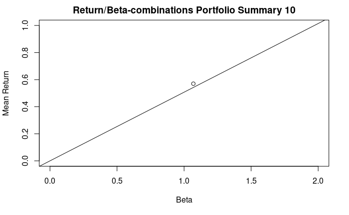

```r
plot.default(x = mean_betas_ten_portf, xlim=c(0, 2),
             y = com_mean_ten_portf_rf, ylim=c(0, 1),
             xlab = "Beta", ylab = "Mean Return",
             main = "Return/Beta-combinations Portfolio Summary 10",
             abline(0, y_mkt))
```